# Capitulo 2

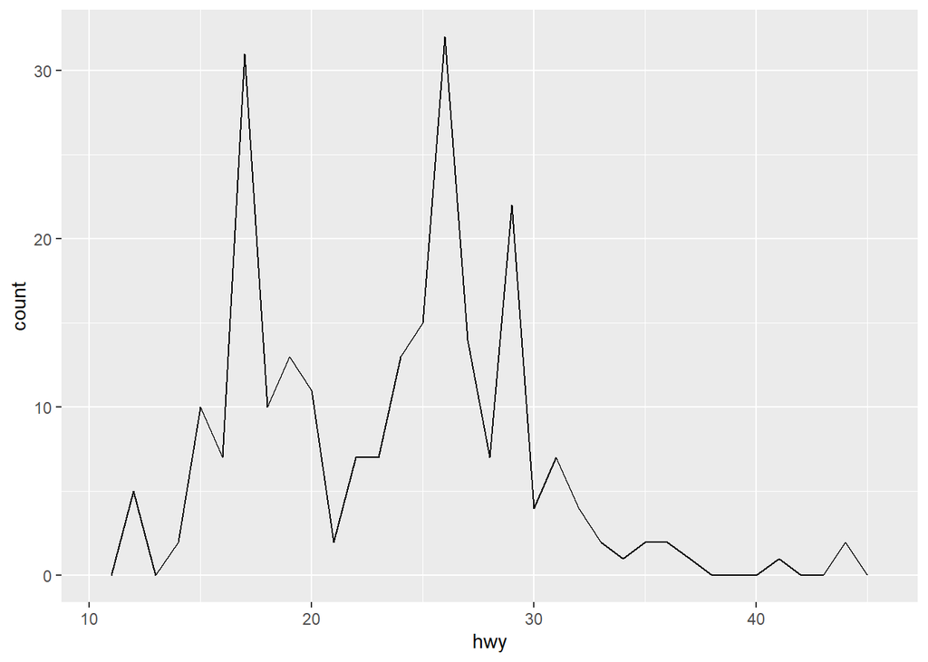

```r
ggplot(mpg, aes(hwy)) + geom_freqpoly(binwidth = 1)
```

Una alternativa es usar `geom_density()`, tienen más computaciones, también suponen que la distribución es continua, sin limites y suavizada.

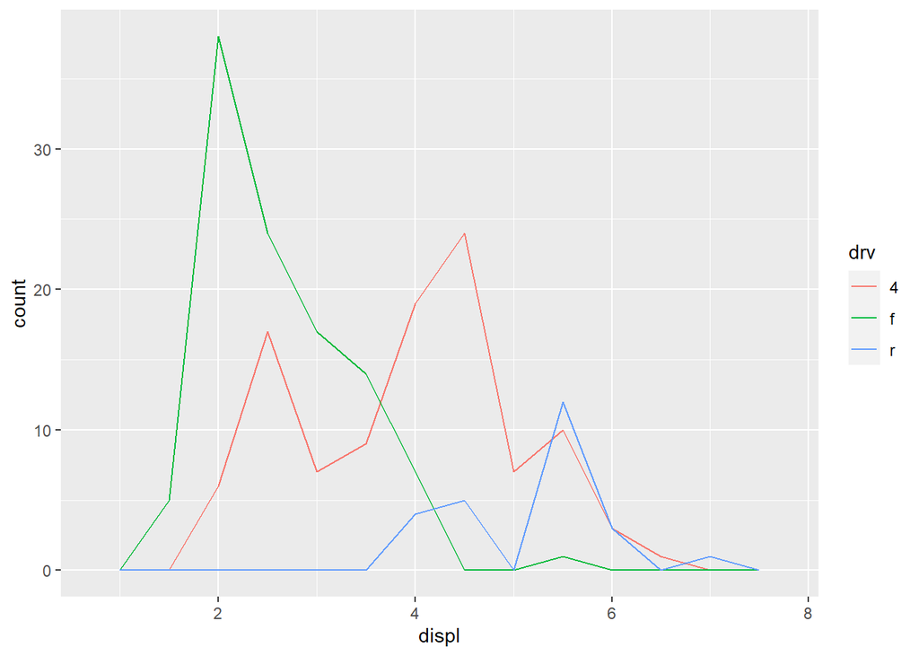

```r
ggplot(mpg, aes(displ, colour = drv)) +
  geom_freqpoly(binwidth = 0.5)
```

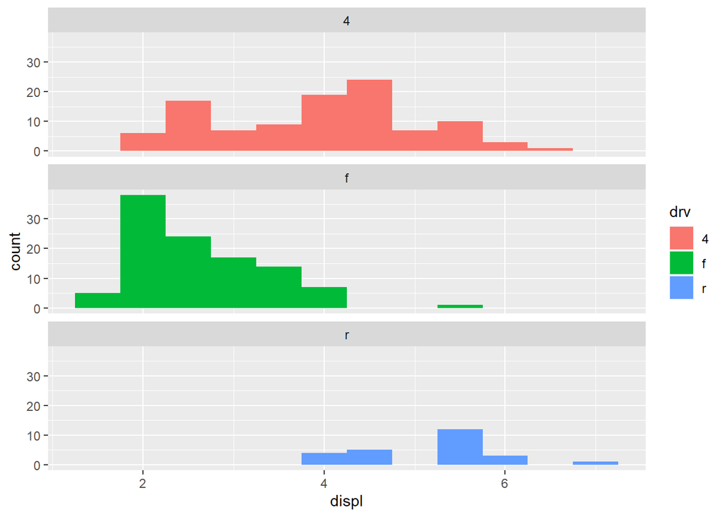

```r
ggplot(mpg, aes(displ, fill = drv)) +
  geom_histogram(binwidth = 0.5) +
  facet_wrap(~drv, ncol = 1)
```

### Graficos de barra

Son el caso discreto del histograma

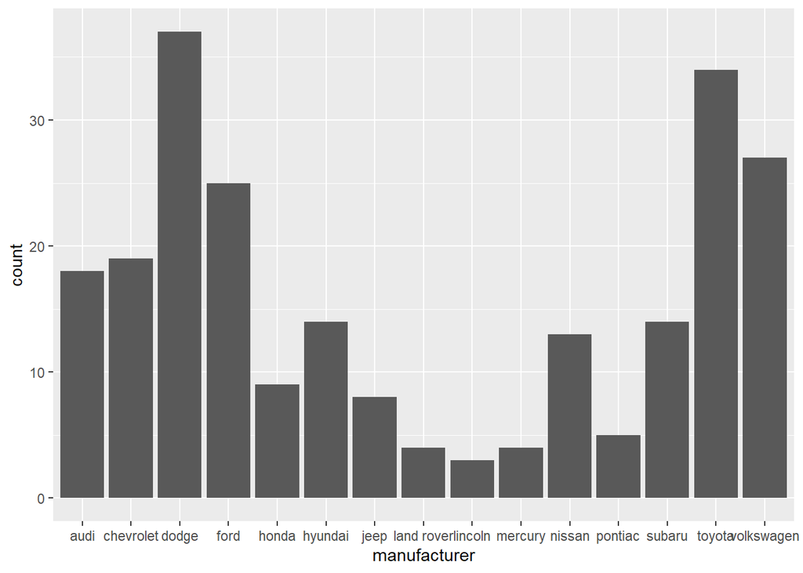

```r
ggplot(mpg, aes(manufacturer)) +
  geom_bar()
```

El gráfico de barra hace por default la cuenta de cuantas obervaciones tiene cada categoría, si queremos que haga otra cosa, tenemos que usar `stat = 'identity'`

```r
drugs <- data.frame(
  drug = c("a", "b", "c"),
  effect = c(4.2, 9.7, 6.1)
)
```

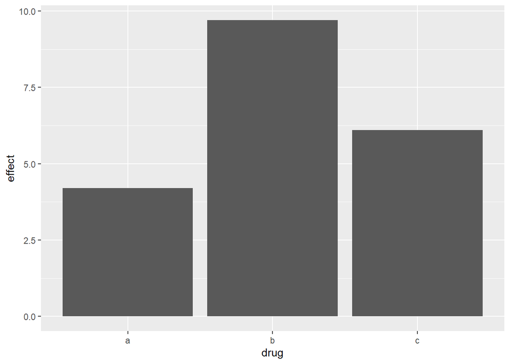

```r
ggplot(drugs, aes(drug, effect)) + geom_bar(stat = "identity")
```

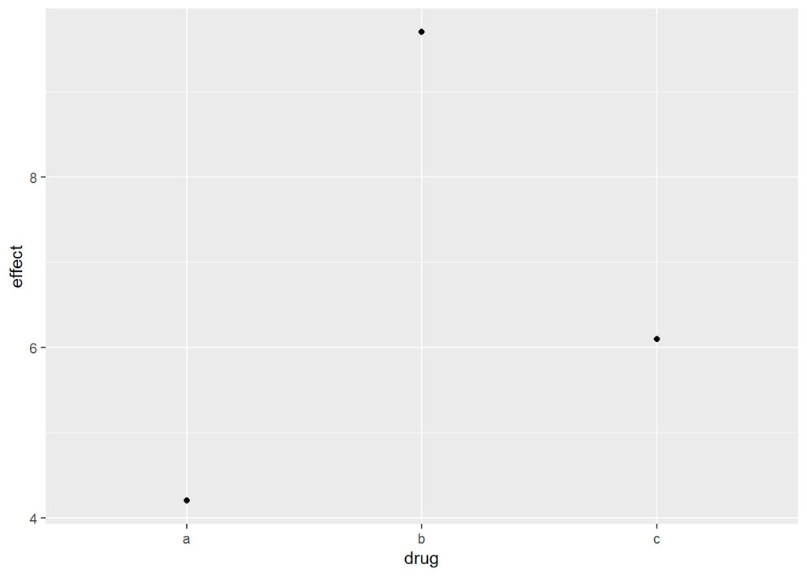

```r
ggplot(drugs, aes(drug, effect)) + geom_point()
```

### Series de tiempo

Graficos de linea unen los punto de izquierda a derecha, los graficos de path unen los puntos en el orden que aparecen el conjunto de datos:

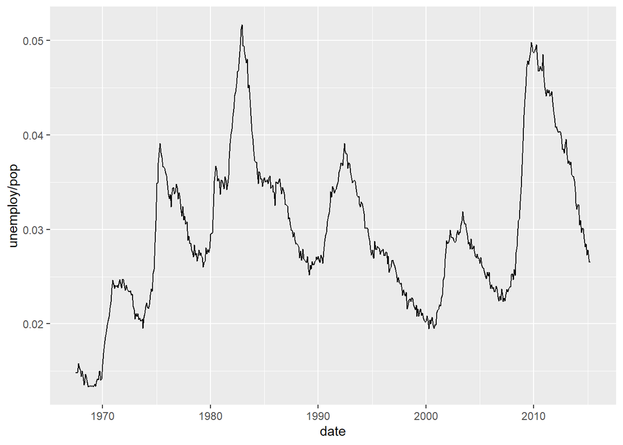

```r
ggplot(economics, aes(date, unemploy / pop)) +
  geom_line()
```

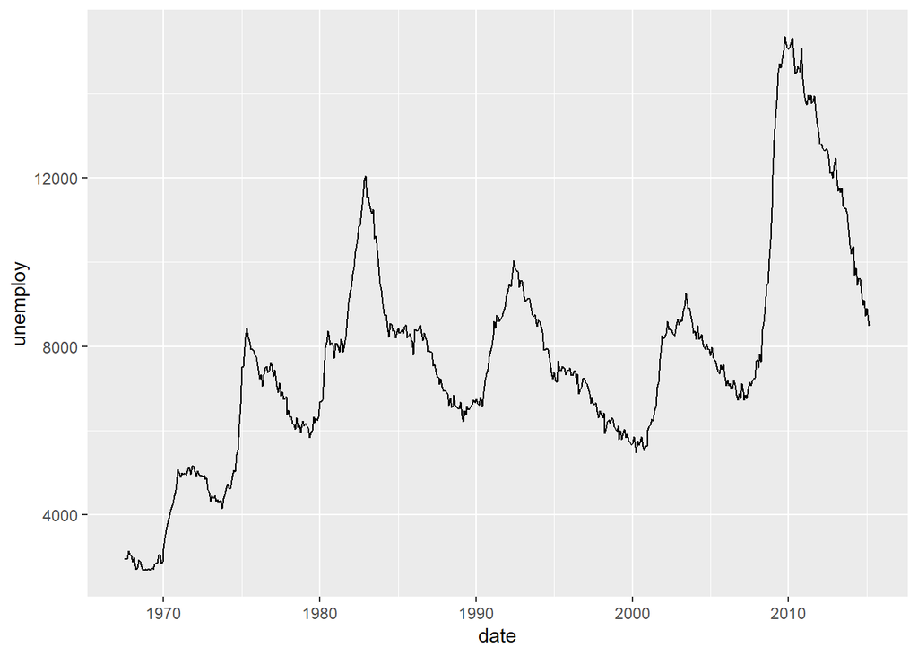

```r
ggplot(economics, aes(date, unemploy)) +
  geom_line()
```

Si quisieramos graficar las dos series en el mismo grafico podemos graficar ambos y usar path para ver como cambian en el tiempo

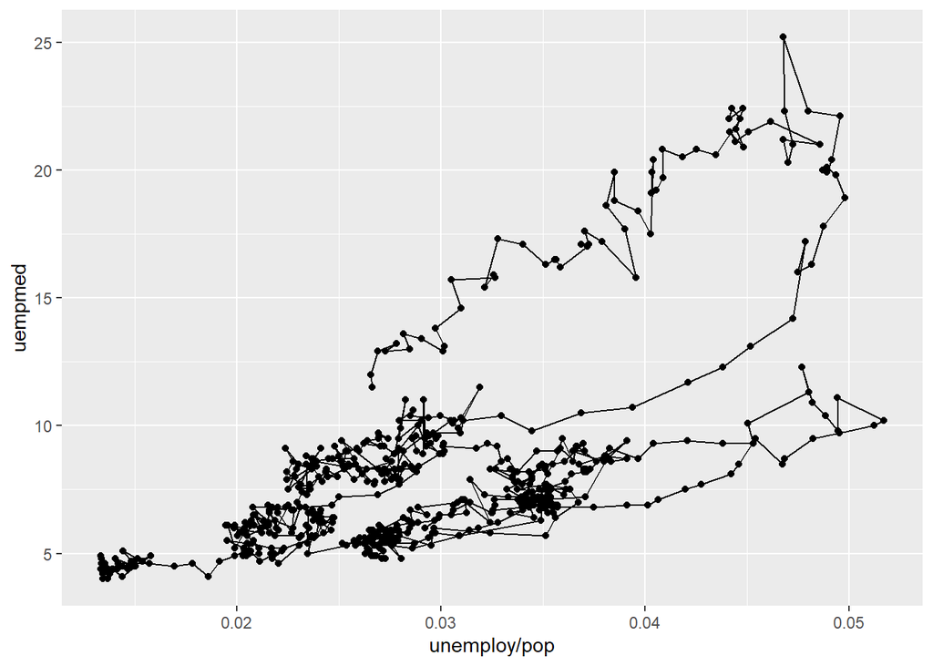

```r
ggplot(economics, aes(unemploy / pop, uempmed)) +
  geom_path() +
  geom_point()
```

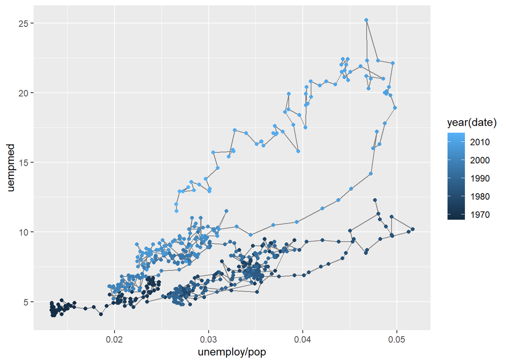

```r
year = function(x) as.POSIXlt(x)$year + 1900
ggplot(economics, aes(unemploy / pop, uempmed)) +
  geom_path(colour = 'grey50') +
  geom_point(aes(colour = year(date)))
```

### Cambiar lo ejes

Podemos cambiar las leyendas con `xlab()` y `ylab()`

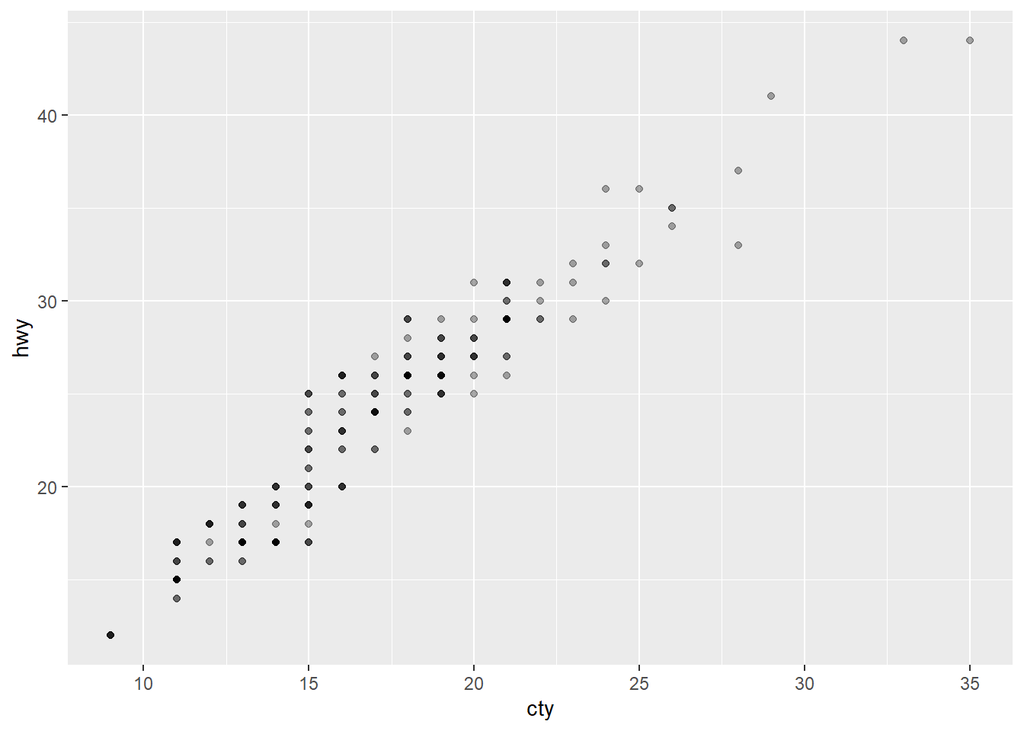

```r
ggplot(mpg, aes(cty, hwy)) +
  geom_point(alpha = 1 /3)
```

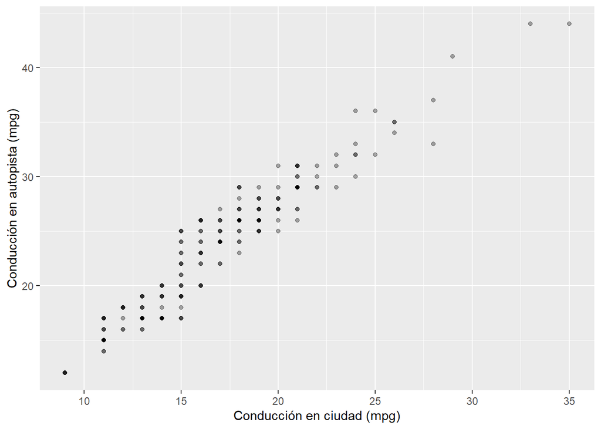

```r
ggplot(mpg, aes(cty, hwy)) +
  geom_point(alpha = 1 / 3) +
  xlab('Conducción en ciudad (mpg)') +
  ylab('Conducción en autopista (mpg)')
```

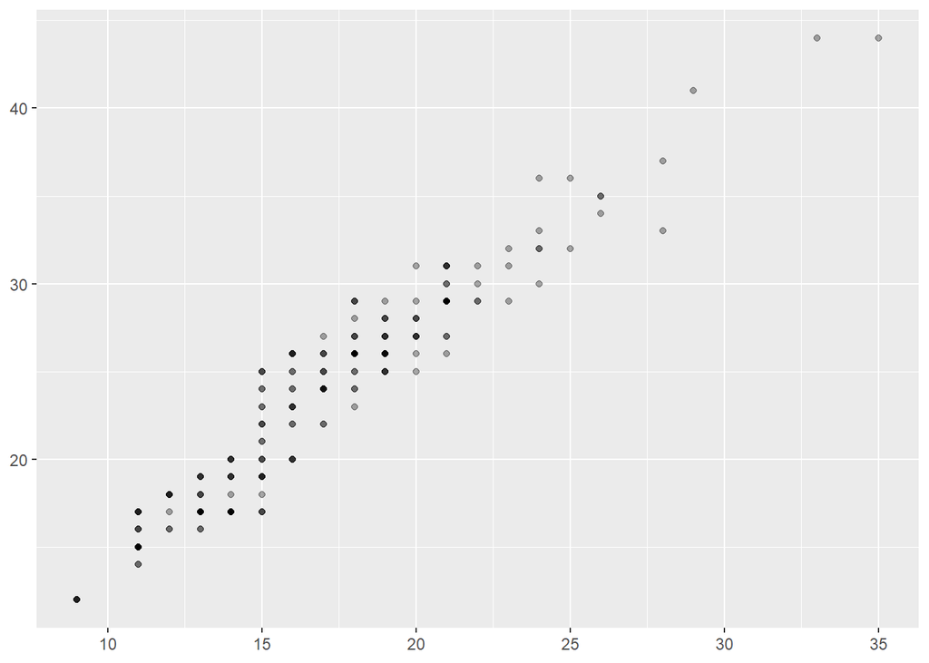

```r
# quitar los labels

ggplot(mpg, aes(cty, hwy)) +
  geom_point(alpha = 1 / 3) +
  xlab(NULL) +
  ylab(NULL)
```

Podemos cambiar los límites de los ejes con `xlim()` y `ylim()`

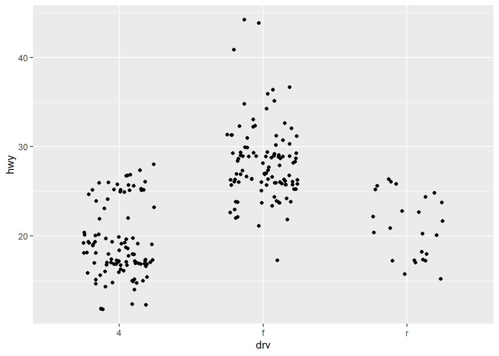

```r
ggplot(mpg, aes(drv, hwy)) +
  geom_jitter(width = 0.25)
```

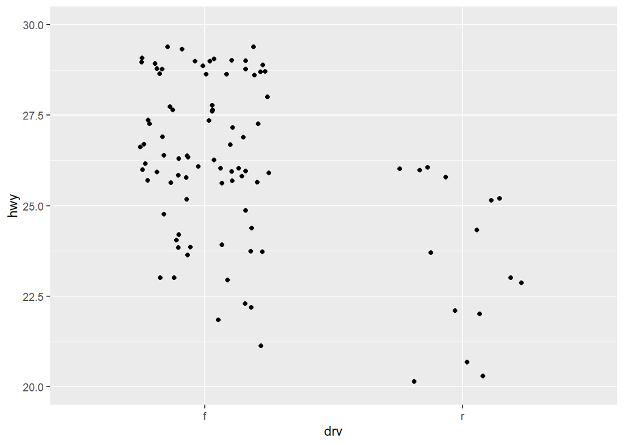

```r
ggplot(mpg, aes(drv, hwy)) +
  geom_jitter(width = 0.25) +
  xlim('f', 'r') +
  ylim(20, 30)
```

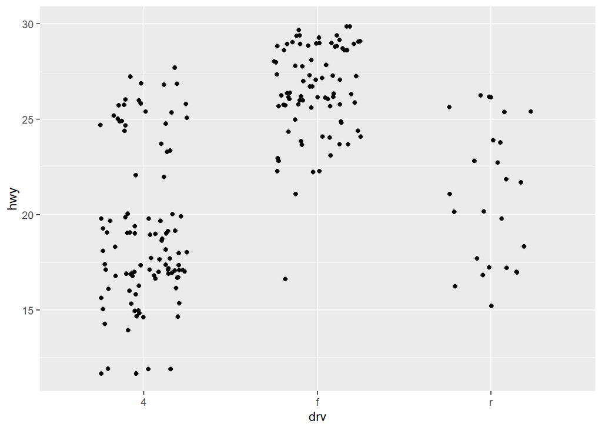

```r
ggplot(mpg, aes(drv, hwy)) +
  geom_jitter(width = 0.25, na.rm = TRUE) +
  ylim(NA, 30)
```

### Salidas

Se puede guardar una gráfica y modificarla

```r
p = ggplot(mpg, aes(displ, hwy, colour = factor(cyl))) +
  geom_point()
```

- Se puede mostrar en pantalla:

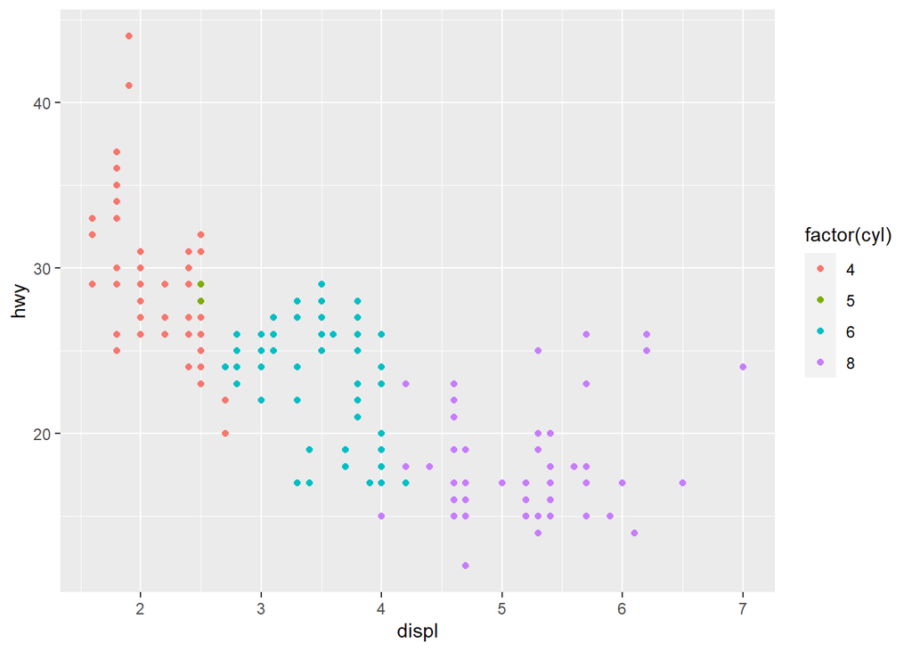

```r
print(p)
```

- Guardar en el computador:

```r
ggsave('grafica.png', p, width = 5, height = 5)
```

- Describir su estructura:

```r
summary(p)
```

```
data: manufacturer, model, displ, year, cyl, trans, drv, cty, hwy, fl,
  class [234x11]
mapping:  x = ~displ, y = ~hwy, colour = ~factor(cyl)
faceting: <ggproto object: Class FacetNull, Facet, gg>
    compute_layout: function
    draw_back: function
    draw_front: function
    draw_labels: function
    draw_panels: function
    finish_data: function
    init_scales: function
    map_data: function
    params: list
    setup_data: function
    setup_params: function
    shrink: TRUE
    train_scales: function
    vars: function
    super:  <ggproto object: Class FacetNull, Facet, gg>
-----------------------------------
geom_point: na.rm = FALSE
stat_identity: na.rm = FALSE
position_identity
```